# Econometrics 1

Nonparametric Methods

Sophie Mathes

4th Quarter 2024

Cameron and Trivedi, Chapter 9

# Intro

### Preview: Nonparametric methods

In all econometric methods you have learned so far, you have some given dataset available, and you have made assumptions about the relationship $g$ between your variables $y=g(x,\beta)$, for example $y=x\beta + u$ or $y=log(x)\beta + u$

These estimations are called “parametric methods” because we already assume the relationship between the variables, and all that is left to do is estimate the *parameters* of these assumed relationships

Nonparametric estimation aims to estimate the relationship between $x$ and $y$ *without* assuming a given relationship ex ante!

One very famous non-parametric estimator are **kernel density estimators**

Kernel density estimators estimate for example the (conditional or unconditional) distribution of a variable $x$

Kernel density estimators are essentially fancy histograms

Another famous non-parametric estimation method are **kernel density regressions**

### Preview: Semiparametric methods

In practice, non-parametric methods require a lot of data, especially when multiple variables are involved, not just one $x$ and one $y$ (“dimensionality curse”)

$\Rightarrow$ invent “Semi-parametric methods”

Assume that the relationship $g(x,\beta)=g(x\beta)$, and estimate $g$

Important application: $g$ might be truncated or censored, e.g. observed wages are never below zero. Classic OLS cannot deal with that

Useful feature: Do not need to make assumptions about error term $u_i$

Convergence typically slower than for parametric models (flexibility comes at a cost)

# Nonparametric methods

## Example: Estimate distribution of hourly wages

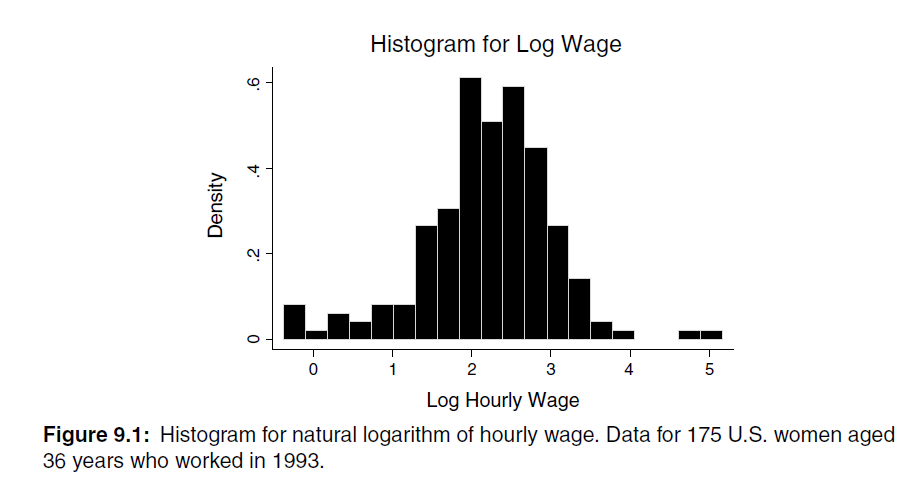

The standard smoothed nonparametric density estimate is the kernel density estimate

A kernel density estimator is based on the logic of a histogram

Nonparametric density estimates are useful 1) to compare different groups and 2) for comparison to a benchmark like the normal distribution

A histogram is a basic density estimator

1. split the domain of $x$ into equally spaced intervals
2. calculate the fraction of the sample in each interval

Estimate the density $f$ of a scalar continuous random variable $x$ at some given point $x_0$

A density is the derivative of a distribution $F$, i.e. $f(x_0) = \left.\frac{\partial F}{\partial x}\right|_{x_0}$ we have

$$f(x_0) = \lim_{h\rightarrow 0}
\frac{F(x_0+h)-F(x_0-h)}{2h}$$

$$f(x_0) = \lim_{h\rightarrow 0}
\frac{P(x_0-h<x<x_0+h)}{2h}$$

## Motivate: Histogram

A histogram estimates a piecewise constant density function
$$\hat{f}_{hist}(x_0)=\frac{1}{n}\sum_{i=1}^n
\frac{I(x_0-h<x_i<x_0+h)}{2h}$$
$I$ is an indicator function that equals 1 if $x_0-h<x<x_0+h$ and 0 otherwise

Notice that this estimator of a density function depends on the choice of “bandwidth” $h$

$\hat{f}_{hist}(x_0)$ is a density estimate centered at $x_0$ with bin width $2h$

It equals the fraction of the sample that lies between $x_0 − h$ and $x_0 + h$, divided by the bin width $2h$. If the number of observations in the bin is the “surface” of the bar, dividing it by the width of the bar gives you the height of the bar

Notice that the estimator $\hat{f}_{hist}(x_0)$ gives all observations in $x_0 \pm h$ equal weight. See this by rewriting the expression above as

$$\hat{f}_{hist}(x_0)=\frac{1}{nh}\sum_{i=1}^n
\frac{1}{2} \cdot I \left(\frac{|x_i - x_0|}{h}<
1\right)$$

## Motivate: Kernels

A histogram is a piecewise constant (not continuous) function, even if the underlying density of $x$ is continuous

How can we estimate a continuous density function?

Idea: Instead of indicator function $I$, use other weighting functions $K$. Compare:
$$\hat{f}_{hist}(x_0)=\frac{1}{nh}\sum_{i=1}^n
\frac{1}{2} \cdot I \left(\frac{|x_i - x_0|}{h}<
1\right)$$

$$\hat{f}(x_0)=\frac{1}{nh}\sum_{i=1}^n
K\left(\frac{x_i - x_0}{h}\right)$$

$K$ is called a **kernel** function, $h$ is called **bandwidth**

# Kernel density estimation

## Definition Kernel density function estimator

$$\hat{f}(x_0):=\frac{1}{nh}\sum_{i=1}^n
K\left(\frac{x_i - x_0}{h}\right)$$
with $h$ bandwidth, $n$ sample size, $K$ a suitable kernel function

## Requirements for kernel functions

### 1. $K$ is symmetric around 0 and is continuous

### 2.

$$\int K(z)dz = 1, \quad \int zK(z)dz = 0,
\quad \int |K(z)|dz < \infty$$

Notice that typical density functions that are centered around zero fulfill this, but not only density functions

### 3. Either

1. $K(z) = 0$ if $|z| \geq z_0$ for some $z_0$,
2. or $|z|K(z) \rightarrow 0$ as $|z| \rightarrow \infty$

$\approx$ the support of $K$ is not the entire real line, or at least $K$ gets really small really fast as $|z|$ goes to infinity

### 4. $\int z^2K(z)dz = \kappa$, where $\kappa$ is a constant

## Examples of kernel functions

- Uniform (or box, or rectangular) $\frac{1}{2}\cdot\mathbb{I}(|z|<1)$
- Triangular (or triangle) $(1-|z|)\cdot\mathbb{I}(|z|<1)$
- Epanechnikov (or quadratic) $\frac{3}{4}\cdot(1-z^2)\cdot\mathbb{I}(|z|<1)$
- Quartic (or biweight) $\frac{15}{16}\cdot(1-z^2)^2\cdot\mathbb{I}(|z|<1)$
- Triweight $\frac{35}{32}\cdot(1-z^2)^3\cdot\mathbb{I}(|z|<1)$
- Tricubic $\frac{70}{81}\cdot(1-|z|^3)^3\cdot\mathbb{I}(|z|<1)$
- Gaussian $(2\pi)^{-1/2}\exp(-z^2/2)$
- Fourth-order Gaussian $\frac{1}{2}(3-z^2)(2\pi)^{-1/2}\exp(-z^2/2)$
- Fourth-order quartic $\frac{15}{32}\cdot(3-10z^2+7z^4)\cdot\mathbb{I}(|z|<1)$

(Which ones do not fulfill 3a?)

The uniform kernel produces *almost* a histogram $\rightarrow$ it is not evaluated at fixed bins but the bins are “endogenous” to the data; $\hat{f}$ is evaluated at each point $x_0$

**p-th order kernel**: first non-zero moment is the $p$-th moment, $\int z^p K(z) dz$

(check kernel requirement 2b, the first moment is required to be zero)

Higher order kernels can increase rates of convergence if the underlying $f$ is more than twice differentiable. Notice higher order kernels may take negative values but that’s ok

## Example: Brazilian Gridded Weather Data

Average daily maximum temperature between 2001-01-01 and 2023-12-31.

$$\hat{f}(x_0)=\frac{1}{nh}\sum_{i=1}^n
K\left(\frac{x_i - x_0}{h}\right)$$

```r
library("tidyverse")
data = readRDS("temperature.Rds") %>% dplyr::filter(year<=2023)
print(summary(data$mean_tmax))
```

```
##    Min. 1st Qu.  Median    Mean 3rd Qu.    Max.
##   24.27   30.39   31.16   31.22   32.07   36.22
```

```r
n = length(data$mean_tmax)
print(n)
```

```
## [1] 8400
```

### Histograms of daily temperatures

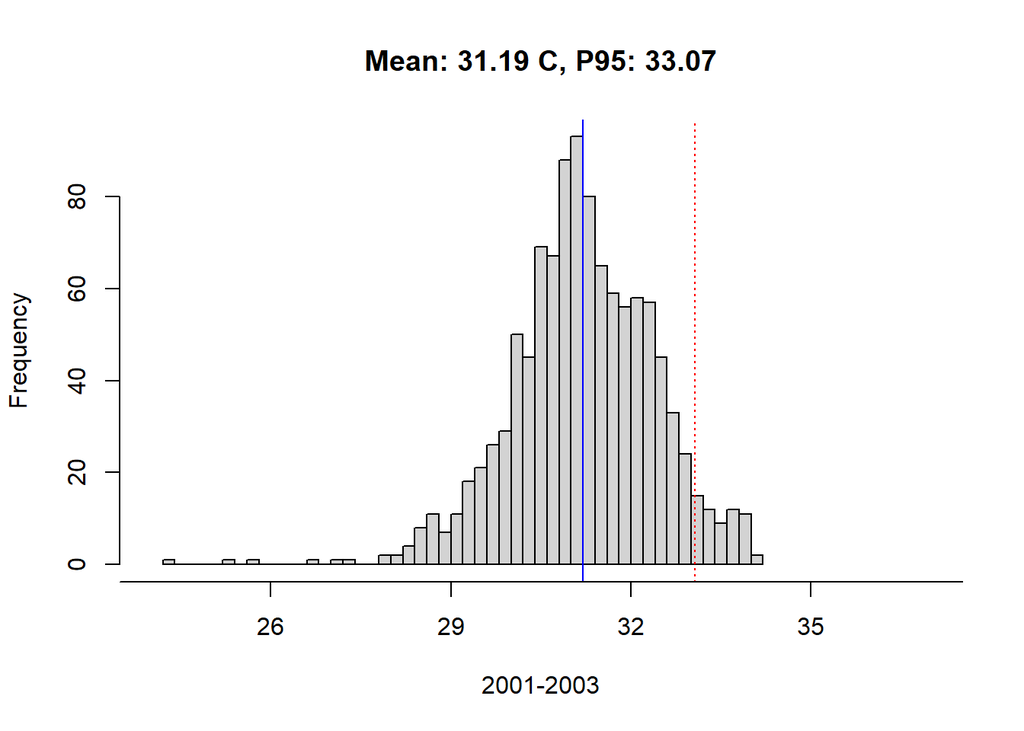

```r
temp = data$mean_tmax[data$year>=2001 & data$year<=2003]
hist(temp,
     main = paste("Mean:", round(mean(temp), 2), "C, P95:", round(quantile(temp, 0.95), 2)),
     breaks=50,
     xlim = c(24,37),
     xlab="2001-2003", xaxt="n")
abline(v=mean(temp), col="blue")
abline(v=quantile(temp, 0.95), col="red", lty=3)
axis(side=1, at=seq(20,40,by=3), labels=seq(20,40,by=3))
```

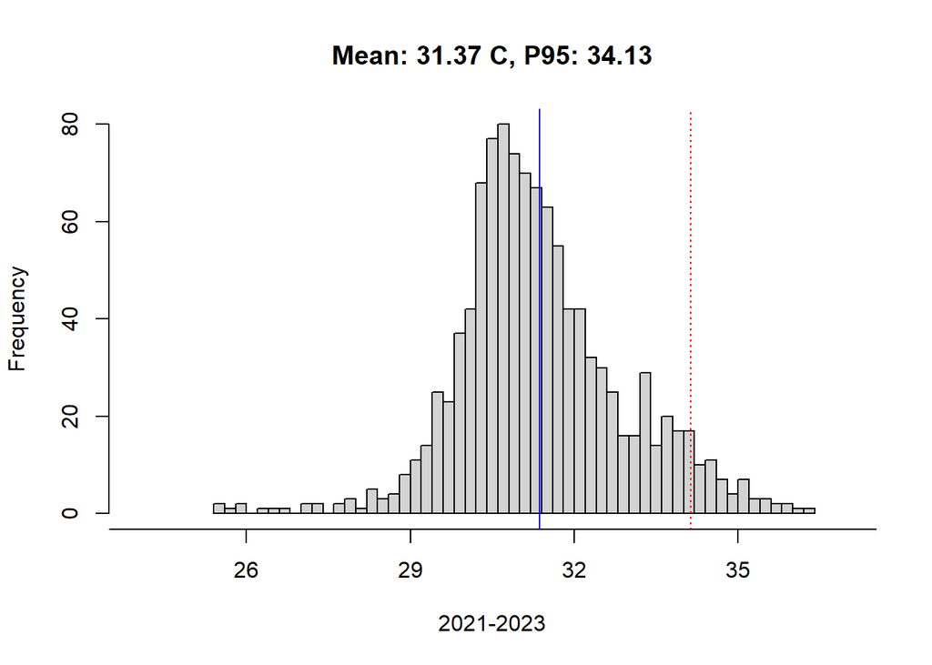

```r
temp = data$mean_tmax[data$year>=2021 & data$year<=2023]
hist(temp,
     main = paste("Mean:", round(mean(temp), 2), "C, P95:", round(quantile(temp, 0.95), 2)),
     breaks=50,
     xlim = c(24,37),
     xlab="2021-2023", xaxt="n")
abline(v=mean(temp), col="blue")
abline(v=quantile(temp, 0.95), col="red", lty=3)
axis(side=1, at=seq(20,40,by=3), labels=seq(20,40,by=3))
```

Use Epanechnikov kernel $\Rightarrow$
$$K(z) = \frac{3}{4} \; (1-z^2) \;
I(|z|<1)$$

### Density function estimate

Estimated density function of daily maximum temperature in Brazil 2001-2023

```r
x = data$mean_tmax
min = floor(min(x))
max = ceiling(max(x))
n = length(data$mean_tmax)[1]
print(n)
```

```
## [1] 8400
```

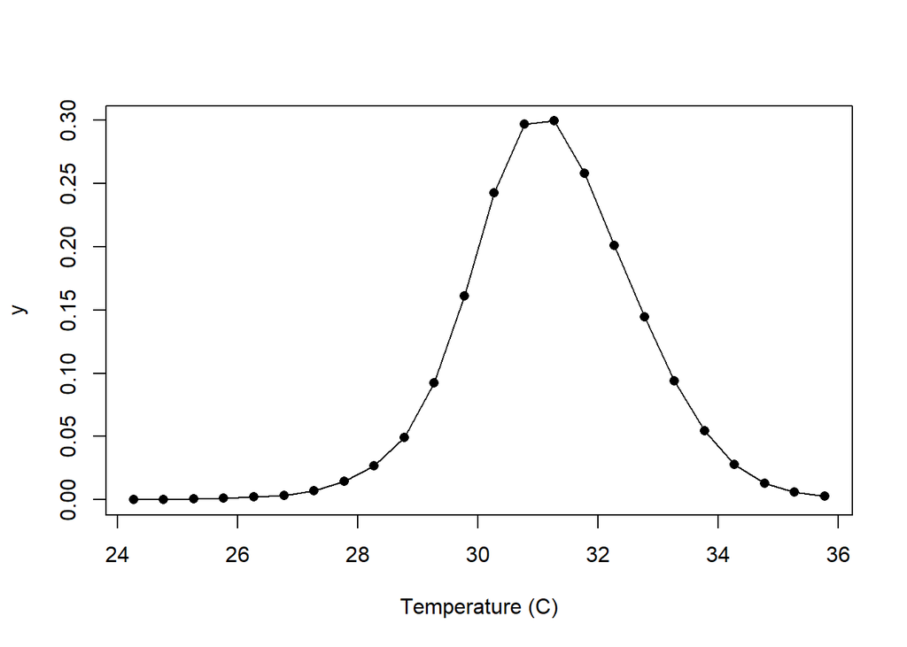

[figure not shown]

```r
h = 1
epanechnikov = function(z) {0.75*(1-z^2)*as.numeric(abs(z)<1)}
f_hat = function(xg) {
  k_argument = (xg - x)/h
  k = epanechnikov(k_argument)
  s = sum(k)/(n*h)
  return(s)
}
xg = seq(min(x), max(x), 0.5)
y = sapply(xg, f_hat)
plot(xg, y, pch=16, xlab="Temperature (C)")
lines(xg, y)
```

## Digression: Landau notation

### Landau $O$ - “Big O”

“Big O notation” - “Bias is of the order $O(h^2)$”

$O$ is “Landau notation” $:\Leftrightarrow$ the function $a$ is of the order $O(h^k)$ iff…

$$\frac{a(h)}{h^k} \stackrel{h\rightarrow
0}{\longrightarrow} t, \quad t \in \mathbb{R}$$

Look at this closely. When $h\rightarrow 0$, then $h^k\rightarrow 0$. Since $h^k$ is in the denominator, $a(h)$ must go to 0 “even faster”, or “just as fast as” $h^k$, in order for the limit to be finite

Example: Consider $a(h)=h^2$. Is $a$ of the order $O(h^3)$? $\frac{h^2}{h^3} = \frac{1}{h} \stackrel{h\rightarrow 0}{\longrightarrow} \infty$, so *No*. $h^2$ goes to zero “a lot slower” than $h^3$

The bias disappears asymptotically if $h\rightarrow 0$ when $n\rightarrow \infty$

### Landau $o$ - “little o”

The Landau $o$ is even stricter than $O$. $a$ is said to be $o(h^k)$ if $\frac{a(h)}{h^k} \stackrel{h\rightarrow 0}{\longrightarrow} 0$

$\rightarrow$ $a$ goes to zero “way faster” than $h^k$. (Notice that $o$ implies $O$)

## Bias

### Properties of kernel density estimator $\hat{f}$

Check whether the kernel density estimator $\hat{f}$ is biased at $x_0$
$$b(x_0) =
E\left(\hat{f}(x_0) - f(x_0)\right) = E\left(\hat{f}(x_0)\right) -
f(x_0)$$
To analyze the bias, consider the expression $E (\hat{f}(x_0))$
$$E\left(\hat{f}(x_0)\right)=E\left(\frac{1}{nh}\sum_{i=1}^n
K(\frac{x_i-x_0}{h})\right)=\frac{1}{nh}\sum_{i=1}^n
E\left(K(\frac{x_i-x_0}{h})\right)$$
$x_i$ are i.i.d.
$$=\frac{1}{nh} \; n \;
E\left(K(\frac{x-x_0}{h})\right) = E\left(\frac{1}{h}
K(\frac{x-x_0}{h})\right) = \int \frac{1}{h}
K(\frac{t-x_0}{h})f(t)dt$$
Substitute $z:=\frac{t-x_0}{h}$, then $t=x_0+zh$ and $\frac{\partial z}{\partial t}=\frac{1}{h}$
$$... = \int K(z)f(x_0+zh)dz$$

$$E\left(\hat{f}(x_0)\right) = \int
K(z)f(x_0+zh)dz$$
Add a second-order Taylor expansion at $f(x_0)$:
$$f(x_0+zh)=f(x_0)+f'(x_0)(x_0+zh-x_0)+\frac{1}{2}f''(x_0)(x_0+zh-x_0)^2+O(h^3)$$
Plug in the expansion
$$E\left(\hat{f}(x_0)\right) = \int K(z)
\left(f(x_0)+f'(x_0)(zh)+\frac{1}{2}f''(x_0)(zh)^2+O(h^3)\right)dz$$
Reformulate
$$... = f(x_0) \int K(z)dz +
hf'(x_0)\int z K(z)dz + \frac{1}{2} h^2 f''(x_0)\int z^2
K(z)dz + O(h^3)$$
Assumptions on kernel functions: $\int K(z)dz = 1$, and $\int zK(z)dz = 0$, therefore
$$E\left(\hat{f}(x_0)\right) = f(x_0) + \frac{1}{2}
h^2 f''(x_0)\int z^2 K(z)dz + O(h^3)$$

$$E\left(\hat{f}(x_0)\right) = f(x_0) +
\frac{1}{2} h^2 f''(x_0)\int z^2 K(z)dz + O(h^3)$$
So we directly get an expression for the bias of $\hat{f}$
$$E\left(\hat{f}(x_0)\right) - f(x_0) = \frac{1}{2}
h^2 f''(x_0)\int z^2 K(z)dz + O(h^3)$$
$\int z^2K(z)dz$ is assumed to be finite, therefore we can conclude that the bias term is of order $O(h^2)$. ($O(h^3)$ implies $O(h^2)$).

So as $n\rightarrow \infty$ and $h\rightarrow 0$, $E(\hat{f}(x_0))$ goes to $f(x_0)$

$\hat{f}(x_0)$ is an asymptotically consistent estimator for $f(x_0)$

### Summary: Bias of kernel density estimator $\hat{f}$

$$b(x_0) = E\left(\hat{f}(x_0)\right) -
f(x_0) = \frac{1}{2} h^2 f''(x_0)\int z^2 K(z)dz +
O(h^3)$$

**Bad news** $\hat{f}$ is biased even with $x$ i.i.d.

**Good news** The bias goes to zero asymptotically if $h\rightarrow 0$ and $n\rightarrow \infty$

The kernel density estimator is biased at $x_0$ with bias term $b(x_0)$ that depends on bandwidth $h$, the curvature of the true $f$, and the kernel $K$

“Bias is of the order $O(h^2)$”

## Variance

### Variance of kernel density estimator $\hat{f}$

$$V(\hat{f}_{x_0})=Var\left(\frac{1}{nh}\sum_i
K(\frac{x_i-x_0}{h})\right)=\frac{1}{n^2}Var(\sum_i
\frac{1}{h}K(\frac{x_i-x_0}{h}))$$
$x_i$ are i.i.d., therefore
$$...=\frac{1}{n^2} \; n \;
Var(\frac{1}{h}K(\frac{x_i-x_0}{h})) = \frac{1}{n} \;
Var\left(\frac{1}{h}K(\frac{x_i-x_0}{h})\right)$$
$$...=\frac{1}{n} \;
E(\left[\frac{1}{h}K(\frac{x_i-x_0}{h})\right]^2) - \frac{1}{n}\left[
\underbrace{E(\frac{1}{h}K(\frac{x_i-x_0}{h}))}_{=E(\hat{f}(x_0))}\right]^2$$

Now consider the first term
$$E(\left[\frac{1}{h}K(\frac{x_i-x_0}{h})\right]^2)
= \int \left[\frac{1}{h}K(\frac{t-x_0}{h})\right]^2 f(t) dt$$

Substitute $z:=\frac{t-x_0}{h}$, $\frac{\partial z}{\partial t}=\frac{1}{h}$
$$\int
\left[\frac{1}{h}K(\frac{t-x_0}{h})\right]^2 f(t) dt = \int
\frac{1}{h}K(z)^2 f(zh+x_0) dz$$
Now Taylor with a first-order expansion $f(zh+x_0)=f(x_0)+f'(x_0)(zh+x_0-x_0)+O(h^2)$
$$= \int \frac{1}{h}K(z)^2
\left(f(x_0)+f'(x_0)zh+ \underbrace{\frac{1}{2}f''(x_0)z^2h^2}_{O(h^2)} \right)
dz$$
Break this up to get
$$E(\left[\frac{1}{h}K(\frac{x_i-x_0}{h})\right]^2)
= \frac{1}{h}f(x_0) \int K(z)^2dz + f'(x_0)\int z K(z)^2 dz +
O(h)$$
Notice that $\frac{1}{h}\frac{1}{2}f''(x_0)z^2h^2 = \frac{1}{2}f''(x_0)z^2h\rightarrow O(h)$

This is an expression we can plug back into $V(\hat{f}(x_0))=\frac{1}{n} \; E(\left[\frac{1}{h}K(\frac{x_i-x_0}{h})\right]^2) - \frac{1}{n}\left[ E(\hat{f}(x_0)\right]^2$

$$V(\hat{f}(x_0))=\frac{1}{nh}f(x_0) \int
K(z)^2dz + \frac{1}{n}f'(x_0)\int z K(z)^2 dz \; + \; \frac{1}{n}
O(h)$$
$$- \; \frac{1}{n}\left[
E(\hat{f}(x_0))\right]^2$$
Use bias term $E(\hat{f}(x_0))-f(x_0)=\frac{1}{2} h^2 f''(x_0)\int z^2 K(z)dz + O(h^3)$ to plug in last term
$$V(\hat{f}(x_0))=\frac{1}{nh}f(x_0) \int
K(z)^2dz + \frac{1}{n}f'(x_0)\int z K(z)^2 dz \; + \; \frac{1}{n}
O(h)$$
$$- \; \frac{1}{n}\left[ f(x_0)
+ \frac{1}{2} h^2 f''(x_0)\int z^2 K(z)dz + O(h^3)
\right]^2$$
Notice that for $n\rightarrow \infty$ and $h\rightarrow 0$ all of these terms disappear *except* the first term. We cannot know what happens to $nh$ if $n\rightarrow \infty$ and $h\rightarrow 0$. But we can check what happens when we assume $nh\rightarrow\infty$ (and thus $\frac{1}{nh}\rightarrow 0$)

$$V(\hat{f}(x_0))=\frac{1}{nh}f(x_0) \int
K(z)^2dz + o\left(\frac{1}{nh}\right)$$

For example, take the second term $\frac{1}{n}f'(x_0)\int z K(z)^2 dz$

$$\frac{\frac{1}{n}f'(x_0)\int z
K(z)^2 dz}{\frac{1}{nh}} = h f'(x_0)\int z K(z)^2 dz
\stackrel{h\rightarrow 0}{\longrightarrow} 0$$
Or the third term $\frac{1}{n} O(h)$ which is a product with the first factor going to zero for $n\rightarrow\infty$ and the second factor going to a constant for $h\rightarrow 0$.

So for the variance of $\hat{f}(x_0)$, we have a term that goes to zero as $nh\rightarrow\infty$, plus other terms that disappear even faster than the first term.

### Summary: Variance of kernel density estimator $\hat{f}$

When $h\rightarrow 0$ and $n\rightarrow \infty$

$$V(\hat{f}(x_0)) = \frac{1}{nh}f(x_0)\int
K(z)^2 dz + o\left(\frac{1}{nh}\right)$$

The variance of $\hat{f}(x_0)$ depends on $K$, $h$, $f$, and $n$!

The variance disappears if $nh\rightarrow \infty$ / when $h\rightarrow 0$ it must be at a slower rate than $n\rightarrow \infty$

## Consistency and asymptotics

The kernel estimator is pointwise consistent (consistent at each point $x = x_0$)

Bias disappears if $h\rightarrow 0$ and $n\rightarrow \infty$

It can even be shown that $\hat{f}$ converges uniformly
$$\sup_{x_0} |\hat{f}(x_0)-f(x_0)|
\stackrel{p}{\rightarrow} 0, \quad \text{if} \;
\frac{nh}{\log(n)}\rightarrow \infty$$

The kernel estimator is asymptotically normal (central limit theorem)

$$\sqrt{nh}(\hat{f}(x_0)-f(x_0)-b(x_0))
\stackrel{d}{\rightarrow} N(0,f(x_0)\int K(z)^2dz)$$

## Bandwidth

How to choose the right bandwidth $h$?

Tradeoff: want to set $h$ small to reduce bias but also want to set $h$ large to get smooth result

Idea: use mean-squared error (MSE, sum of squared bias and variance) to find the right balance

$$MSE(\hat{f}(x_0)) = E\left[ \left(
\hat{f}(x_0) - f(x_0) \right)^2 \right]$$
$$= Var(\hat{f}(x_0) - f(x_0)) +
E\left[\hat{f}(x_0) - f(x_0) \right]^2$$

Remember the bias is: $b(x_0)=E(\hat{f}(x_0))-f(x_0) = \frac{1}{2} h^2 f''(x_0) \int z^2 K(z) dz$

…and the variance is $V(\hat{f}(x_0)) = \frac{1}{nh}f(x_0)\int K(z)^2 dz + o\left(\frac{1}{nh}\right)$

Bias is $O(h^2)$ and the variance is $O(\frac{1}{nh})$ $\Rightarrow$ the square of the bias is $O(h^4)$ (why?)

Square of bias is $O(h^4)$ and the variance is $O(\frac{1}{nh})$

We know that the bias-squared goes to zero “not much slower than $h^4$” and the variance goes to zero “not much slower than $\frac{1}{nh}$” $\rightarrow$ pick $h$ such that the terms go to zero “at the same speed”

$$h^4 \stackrel{!}{=} \frac{1}{nh} \quad
\Rightarrow \quad h^*= \left(\frac{1}{n}\right)^{0.2}$$

With this choice of $h$, the MSE goes to zero as $n\rightarrow \infty$ $\checkmark$

The MSE at $\hat{f}(x_0)$ is a *local* measure of performance, specifically at $x_0$

But we are estimating a whole function $\hat{f}$! Is the locally optimal bandwidth also the globally optimal bandwidth? Can we do better than $h=n^{-0.2}$? Generalize the Mean Squared Error (MSE). “Sum up” the squared errors into the Integrated Squared Error (ISE)
$$ISE(h) = \int
(\hat{f}(x_0)-f(x_0))^2 dx_o$$

Look at this, we are simply “summing up” all squared errors over all $x_0$. And now we take the mean over this, call it **Mean Integrated Squared Error**

$$MISE(h) = E(ISE(h)) = E\left(\int
(\hat{f}(x_0)-f(x_0))^2 dx_o\right)$$
$$= \int \left(E (\hat{f}(x_0)-f(x_0))^2\right)
dx_o$$
$$= \int MSE(\hat{f}(x_0))
dx_o$$

Idea for “globally optimal” bandwidth $h$: Minimize $MISE(h)$

How do we minimize a function if it is continuously differentiable and (hopefully) convex? Set the first derivative to zero and solve.

$$MISE(h) = \int MSE(\hat{f}(x_0)) dx_o =
\int b(x_0)^2 + Var(\hat{f}(x_0)) dx_o$$
Take first derivative w.r.t. $h$
$$\frac{\partial MISE}{\partial h}= \int
2b(x_0)\frac{\partial b}{\partial h} + \frac{\partial
Var(\hat{f}(x_0))}{\partial h} dx_o \stackrel{!}{=} 0$$
We can use the bias and variance terms derived before to find first derivatives and solve

$$h^*=\delta \left(\int f''(x_0)^2
dx_0 \right)^{-0.2}n^{-0.2}, \quad \text{with} \; \delta =
\left(\frac{\int K(z)^2dz}{(\int z^2K(z)dz)^2}\right)^{0.2}$$
Proof in Silverman (1986)

1. Notice the optimal bandwidth depends on the choice of kernel
2. This optimal bandwidth is not constructive because it requires the knowledge of $\int f''(x_0)^2 dx_0$ and $f$ is what we are aiming to estimate. Options?

## Plug-in Bandwidth Estimate

Assume $f$ follows a normal density, calculate $\int f''(x_0)^2 dx_0$ for a normal density and ‘plug in’ $\int f''(x_0)^2 dx_0=3/(8\sqrt{\pi}\sigma^5)$

Then the optimal bandwidth is $h^*=1.364\delta n^{-0.2}s$, with $s$ sample standard deviation of $x$, $\delta$ depends on the kernel

Epanechnikov kernel: $h^*=2.345 n^{-0.2}s$

Gaussian kernel: $h^*=1.059 n^{-0.2}s$

The Silverman plug-in estimate is: $h^*=1.3643\delta n^{-0.2}\min(s,iqr/1.349)$

# Nonparametric regression

## Nonparametric local regression

We want to estimate a relationship between variables $x$ and $y$, without making parametric assumptions on the structure of the relationship. Let’s assume the draws are i.i.d. and the error term $\varepsilon_i$ is i.i.d. with mean 0 and some variance $\sigma^2_{\varepsilon}$
$$y_i = g(x_i) + \varepsilon_i$$
There is no functional form specified for $g$; also no functional form specified for the distribution of $\varepsilon$

## Local weighted average estimator

Suppose there are $n_0$ observations with $x$ value $x_0$: $(x_0, y_1), (x_0, y_2),...,(x_0,y_{n_0})$

Estimate the value of $g(x_0)$ using an average of all $y$ values at $x_0$: $\bar{g}(x_0)$
$$\hat{g}(x_0)=\bar{g}(x_0)$$
The distribution of $\hat{g}(x_0)$ has mean $g(x_0)$ and variance $\frac{1}{n_0}\sigma^2_{\varepsilon}$ (why?)

In practice: $\hat{g}(x_0)$ may be noisy, especially if $x$ is a continuous variable and only very few observations are exactly at $x=x_0$

$\hat{g}(x_0)$ is unbiased but need not be consistent (not in practice, but yes in theory)

Improvement over $\hat{g}(x_0)=\bar{g}(x_0)$: use observations with values of $x$ in a small neighborhood of $x_0$

To start, rewrite $\hat{g}$
$$\hat{g}(x_0) = \sum_{i=1}^n w_{i0} y_i \quad
\cases{w_{i0}=\frac{1}{n_0} \quad \forall x_i=x_0 \\ w_{i0}=0 \quad
\forall x_i\neq x_0}$$
To improve, replace $w_{i0}$ with $w_{i0h}$
$$\hat{g}(x_0) = \sum_{i=1}^n w_{i0h} y_i \quad
\text{with} \quad w_{i0h}=w(x_i,x_0,h) \quad \text{and} \quad \sum_i
w_{i0h}=1$$
Notice that $h$ is the bandwidth in the Kernel regression case, for methods other than Kernel called “window width”

### Example: OLS

We can write the OLS estimator in this form if we use the following weights
$$\hat{g}_{OLS}(x_0) = \sum_{i=1}^n
\left( \frac{1}{n} + \frac{(x_0-\bar{x})(x_i-\bar{x})}{\sum_j
(x_j-\bar{x})^2} \right) y_i$$

### Example: K-Nearest neighbors (moving average)

Sort the $(x,y)$ sample by $x$ values. Pick the $(k-1)/2$ values closest to $x_0$ with $x<x_0$, and the $(k-1)/2$ values closest to $x_0$ with $x>x_0$
$$\hat{g}_k(x_0) =
\frac{1}{k}(y_{i-(k-1)/2}+...+y_{i+(k-1)/2})$$
This can also be written in the form $\hat{g}(x_0) = \sum_{i=1}^n w_{i0k} y_i$ with
$$w_{i0k} = \frac{1}{k} \;
I\left(|i-0|<\frac{k-1}{2}\right)$$
Here $k$ is some sort of bandwidth/window width. Example: covid cases, hospital admissions

### Inference

Properties of $\hat{g}(x_0)$? Start with definition and $y_i=g(x_i)+\varepsilon_i$, assuming fixed regressors $x_i$
$$\hat{g}(x_0) = \sum_{i=1}^n w_{ioh}y_i =
\sum_{i=1}^n w_{ioh}(g(x_i)+\varepsilon_i) = \sum_{i=1}^n w_{ioh}g(x_i)
+\sum_{i=1}^n w_{ioh}\varepsilon_i$$
$$\Rightarrow \hat{g}(x_0) - \sum_{i=1}^n
w_{ioh}g(x_i) = \sum_{i=1}^n w_{ioh}\varepsilon_i$$
So with $\varepsilon_i$ i.i.d. with $N(0,\sigma^2_{\varepsilon})$ we get that
$$\hat{g}(x_0) \sim N\left(\sum_{i=1}^n
w_{ioh}g(x_i), \sigma^2_{\varepsilon}\sum_{i=1}^n
w^2_{ioh}\right)$$
The variance term is useful, the mean term is not super useful. Is there bias? Quite probably
$$E(\hat{g}(x_0))=E\left(\sum_{i=1}^n
w_{ioh}g(x_i)\right) + E\left(\sum_{i=1}^n
w_{ioh}\varepsilon_i\right)=\sum_{i=1}^n w_{ioh}E(g(x_i))$$

## Kernel regression estimator

Let’s consider the Local weighted average estimator with Kernel weights. Assume $y=m(x)+\varepsilon$. Start with the local average estimator for a given bandwidth $h$
$$\hat{g}(x_0) = \sum_{i=1}^n w_{i0h} y_i \quad
\text{with} \quad w_{i0h}=w(x_i,x_0,h) \quad \text{and} \quad \sum_i
w_{i0h}=1$$

Equally weight all observations in a neighborhood of $x_0\pm h$, disregard all other observations
$$\hat{g}(x_0)=\sum_{i=1}^n
\frac{I(|\frac{x_i-x_0}{h}|<1) \; y_i}{\sum_{j=1}^n
I(|\frac{x_j-x_0}{h}|<1)}$$
Move from equal weights to Kernel weights. Replace the indicator function with a kernel, meet the **Nadaraya-Watson estimator**

### Local constant estimator / Nadaraya-Watson estimator

$$\hat{m}_{nw}(x_0)=\frac{\frac{1}{nh}\sum_{i=1}^n
K(\frac{x_i-x_0}{h}) \; y_i}{\frac{1}{nh}\sum_{j=1}^n
K(\frac{x_j-x_0}{h})}$$
This is a special case of a local weighted average estimator, with weights
$$w_{i0h}=\frac{\frac{1}{nh}K(\frac{x_i-x_0}{h})}{\frac{1}{nh}\sum_{j=1}^n
K(\frac{x_j-x_0}{h})} =
\frac{\frac{1}{nh}K(\frac{x_i-x_0}{h})}{\hat{f}(x_0)}$$
Weights still sum to 1 $\checkmark$

Nadaraya-Watson estimator also called **local constant** estimator, because at each point, a regression on a constant is conducted.

$$\hat{m}_{nw}(x)=\arg \min_m \sum_{i=1}^n
k\left(\frac{x_i-x}{h}\right)(y_i-m)^2$$

> `demo_kernel_regression.R`

### Consistency $\hat{m}_{nw}(x)$ (CT Chapter 9)

Assume regressors $x_i$ are i.i.d. with density $f$, the true process is $y_i=m(x_i)+\varepsilon_i$, kernel estimator $\hat{m}(x_0)=\sum_i w_{ioh}y_i$ with
$$w_{ioh}=\frac{\frac{1}{nh}K(\frac{x_i-x_0}{h})}{\frac{1}{nh}\sum_i
K(\frac{x_i-x_0}{h})}$$

To find the asymptotic distribution of the NW estimator $\hat{m}$, analyze the following expression
$$\sqrt{nh}(\hat{m}(x_0)-m(x_0)) =
\sqrt{nh}\sum_{i=1}^nw_{i0h}(m(x_i)-m(x_0)+\varepsilon_i)$$

Plug in definition of $w_{i0h}$, denominator is identical
$$\sqrt{nh}(\hat{m}(x_0)-m(x_0)) =
\sqrt{nh}\frac{\frac{1}{nh}\sum_{i=1}^n
K(\frac{x_i-x_0}{h})(m(x_i)-m(x_0)+\varepsilon_i)}{\hat{f}(x_0)}=
\frac{1}{\sqrt{nh}}\frac{\sum_{i=1}^n
K(\frac{x_i-x_0}{h})(m(x_i)-m(x_0)+\varepsilon_i)}{\hat{f}(x_0)}$$

Break up the numerator
$$\frac{1}{\sqrt{nh}} \sum_{i=1}^n
K\left(\frac{x_i-x_0}{h}\right)(m(x_i)-m(x_0)) + \frac{1}{\sqrt{nh}}
\sum_{i=1}^n K\left(\frac{x_i-x_0}{h}\right) \varepsilon_i$$

Now find the expected value of this term.

Notice that the second term is zero in expectation **if** $x_i$ and $\varepsilon_i$ are assumed to be independent $cov(x,\varepsilon)=0$. Focus on the first term

$$E\left(\frac{1}{\sqrt{nh}} \sum_{i=1}^n
K\left(\frac{x_i-x_0}{h}\right)(m(x_i)-m(x_0))\right)$$
Remember that $x_i$ i.i.d. …

$$=\frac{1}{\sqrt{nh}}nE\left(K\left(\frac{x-x_0}{h}\right)(m(x)-m(x_0))\right)$$
$$=\frac{\sqrt{n}}{\sqrt{h}}\int
K\left(\frac{x-x_0}{h}\right)(m(x)-m(x_0))f(x)dx$$

Substitute with $z=(x-x_0)/h$, need to expand with $\frac{h}{h}$
$$=\sqrt{nh}\int
K(z)(m(x_0+hz)-m(x_0))f(x_0+hz)dz$$
Taylor twice! First order at $f(x_0)$, second order at $m(x_0)$
$$=\sqrt{nh}\int
K(z)(m'(x_0)zh+m''(x_0)\frac{1}{2}h^2z^2)(f(x_0)+hzf'(x_0))dz$$

Now we get 4 terms in the sum. One of them contains $h^3$, so we ignore it asymptotically. One term contains $\int z K(z)$ which is zero. Remaining two terms:

$$=\sqrt{nh}\left(\int K(z) h^2z^2
m'(x_0)f'(x_0)dz+\int K(z)\frac{1}{2}h^2
z^2m''(x_0)f(x_0))dz\right)$$

$$=\sqrt{nh}h^2 (m'(x_0)f'(x_0) +
\frac{1}{2}m''(x_0)f(x_0)) \left(\int z^2 K(z)
dz\right)$$
Define the term $b(x_0)$ “the bias term of the kernel regression estimator”
$$b_0 := h^2
(m'(x_0)\frac{f'(x_0)}{f(x_0)} + \frac{1}{2}m''(x_0))
\left(\int z^2 K(z) dz\right)$$
such that we get

$$E\left[\sqrt{nh}(\hat{m}(x_0)-m(x_0))\right]=\sqrt{nh}\frac{f(x_0)}{\hat{f}(x_0)}b(x_0)$$

If we can be sure that $\hat{f}(x_0)\stackrel{p}{\rightarrow}f(x_0)$, then we have a bias term of order $O(h^2)$ in the limit.

$\hat{m}(x_0)\rightarrow m(x_0)$ requires $h\rightarrow 0$, but also need a large enough “sample size” around $x_0$

$\hat{m}(x_0)\stackrel{p}{\rightarrow} m(x_0)$ if $h\rightarrow 0$ and $nh\rightarrow \infty$ with the bias term

$$b(x_0)=h^2\left(m'(x_0)\frac{f'(x_0)}{f(x_0)}
+ \frac{1}{2}m''(x_0) \right) \int z^2 K(z)dz$$

### Local linear estimator

The **local linear** estimator minimizes the weighted residual sum of squares at each $x$

$$\hat{m}_{ll}(x)=\arg \min_{\alpha,\beta}
\sum_{i=1}^n
k\left(\frac{x_i-x}{h}\right)(y_i-\alpha-\beta(x_i-x))^2$$
This is a linear regression with regressors $z_i=(1, x_i-x)$
$$\hat{\beta}_{LL} = \left(\sum_{i=1}^n k
\left(\frac{x_i-x}{h}\right) z_i(x)z_i(x)' \right)^{-1}\sum_{i=1}^n
k \left(\frac{x_i-x}{h}\right) z_i(x)y_i$$
$$=(Z'KZ)^{-1}Z'Ky$$
$K$ is a diagonal matrix with $k(\frac{x_i-x}{h})$ on each element $i$ on the main diagonal

> `demo_kernel_regression.R`